# MD5 Demo

Stephen Vaisey

2022-10-13

Load packages and set theme.

```r
library(tidyverse)
library(moderndive)
library(ggthemes)
library(patchwork)
theme_set(theme_pander())
```

Let’s look at the MD evaluations data.

```r
data(evals)
glimpse(evals)
```

```
## Rows: 463
## Columns: 14
## $ ID           <int> 1, 2, 3, 4, 5, 6, 7, 8, 9, 10, 11, 12, 13, 14, 15, 16, 17…
## $ prof_ID      <int> 1, 1, 1, 1, 2, 2, 2, 3, 3, 4, 4, 4, 4, 4, 4, 4, 4, 5, 5, …
## $ score        <dbl> 4.7, 4.1, 3.9, 4.8, 4.6, 4.3, 2.8, 4.1, 3.4, 4.5, 3.8, 4.…
## $ age          <int> 36, 36, 36, 36, 59, 59, 59, 51, 51, 40, 40, 40, 40, 40, 4…
## $ bty_avg      <dbl> 5.000, 5.000, 5.000, 5.000, 3.000, 3.000, 3.000, 3.333, 3…
## $ gender       <fct> female, female, female, female, male, male, male, male, m…
## $ ethnicity    <fct> minority, minority, minority, minority, not minority, not…
## $ language     <fct> english, english, english, english, english, english, eng…
## $ rank         <fct> tenure track, tenure track, tenure track, tenure track, t…
## $ pic_outfit   <fct> not formal, not formal, not formal, not formal, not forma…
## $ pic_color    <fct> color, color, color, color, color, color, color, color, c…
## $ cls_did_eval <int> 24, 86, 76, 77, 17, 35, 39, 55, 111, 40, 24, 24, 17, 14, …
## $ cls_students <int> 43, 125, 125, 123, 20, 40, 44, 55, 195, 46, 27, 25, 20, 2…
## $ cls_level    <fct> upper, upper, upper, upper, upper, upper, upper, upper, u…
```

We are going to ask whether the “beauty” of an instructor predicts their teaching evaluations. Let’s simplify the dataset so we can really look at it.

```r
set.seed(1015)                            # for replicable results

d <- evals |>
  mutate(random = runif(nrow(evals))) |>  # as many random numbers as rows
  arrange(prof_ID, random) |>             # sort by random within groups
  group_by(prof_ID) |>                    # group it
  slice(1) |>                             # keep only one per prof
  select(prof_ID, score, bty_avg) |>      # keep vars we need
  rename(bty = bty_avg) |>                # shorter is better for me
  ungroup()                               # just for completeness

glimpse(d)
```

```
## Rows: 94
## Columns: 3
## $ prof_ID <int> 1, 2, 3, 4, 5, 6, 7, 8, 9, 10, 11, 12, 13, 14, 15, 16, 17, 18,…
## $ score   <dbl> 4.1, 2.8, 4.1, 3.9, 4.8, 4.5, 4.4, 2.5, 4.5, 4.6, 3.7, 4.7, 4.…
## $ bty     <dbl> 5.000, 3.000, 3.333, 3.167, 7.333, 5.500, 4.167, 4.000, 4.667,…
```

Let’s look at the first few cases.

```r
head(d)
```

```
## # A tibble: 6 × 3
##   prof_ID score   bty
##     <int> <dbl> <dbl>
## 1       1   4.1  5
## 2       2   2.8  3
## 3       3   4.1  3.33
## 4       4   3.9  3.17
## 5       5   4.8  7.33
## 6       6   4.5  5.5
```

We can use the **skimr** package for summary statistics if we want. There are lots of ways to do this.

```r
library(skimr)
skim(d)
```

Data summary

| Name | d |
| --- | --- |
| Number of rows | 94 |
| Number of columns | 3 |
| _______________________ |  |
| Column type frequency: |  |
| numeric | 3 |
| ________________________ |  |
| Group variables | None |

**Variable type: numeric**

| skim_variable | n_missing | complete_rate | mean | sd | p0 | p25 | p50 | p75 | p100 | hist |
| --- | --- | --- | --- | --- | --- | --- | --- | --- | --- | --- |
| prof_ID | 0 | 1 | 47.50 | 27.28 | 1.00 | 24.25 | 47.50 | 70.75 | 94.00 | ▇▇▇▇▇ |
| score | 0 | 1 | 4.04 | 0.61 | 2.30 | 3.60 | 4.10 | 4.50 | 4.90 | ▁▁▅▆▇ |
| bty | 0 | 1 | 4.60 | 1.59 | 1.67 | 3.33 | 4.33 | 5.79 | 8.17 | ▃▇▇▅▂ |

You could also just use `summary()`. You don’t get the cool little histograms, though.

```r
summary(d)
```

```
##     prof_ID          score            bty
##  Min.   : 1.00   Min.   :2.300   Min.   :1.667
##  1st Qu.:24.25   1st Qu.:3.600   1st Qu.:3.333
##  Median :47.50   Median :4.100   Median :4.333
##  Mean   :47.50   Mean   :4.041   Mean   :4.599
##  3rd Qu.:70.75   3rd Qu.:4.500   3rd Qu.:5.792
##  Max.   :94.00   Max.   :4.900   Max.   :8.167
```

It’s always good practice to look at the distributions of each variable.

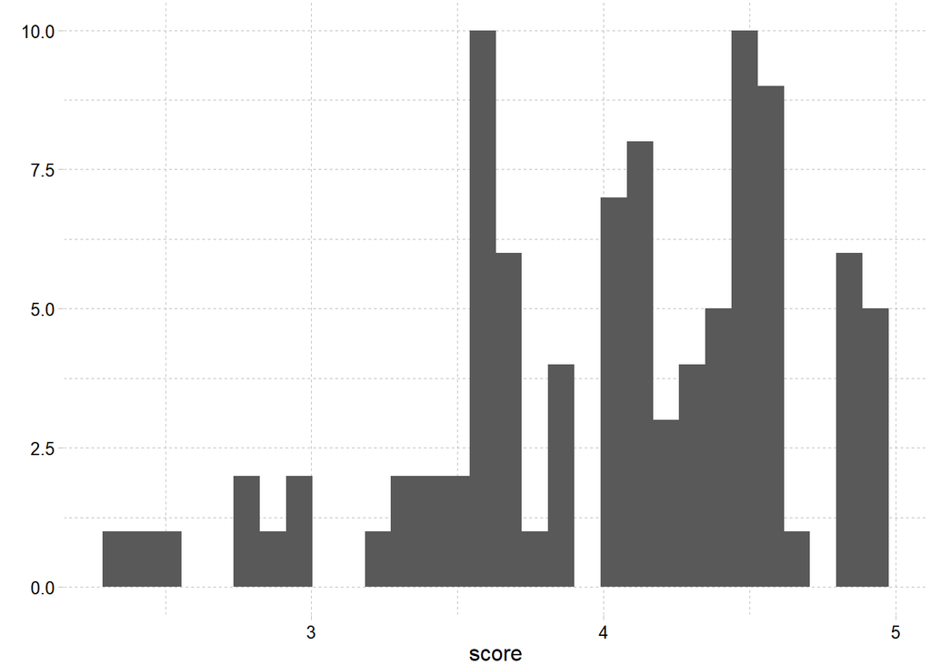

```r
qplot(score, data = d)
```

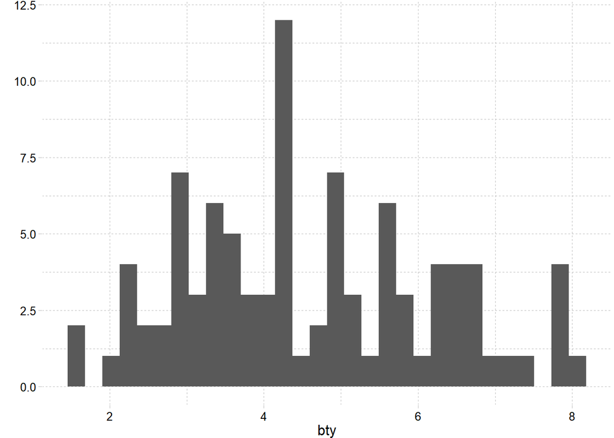

```r
qplot(bty, data = d)
```

Let’s look at the data, using `geom_jitter()` to avoid overplotting.

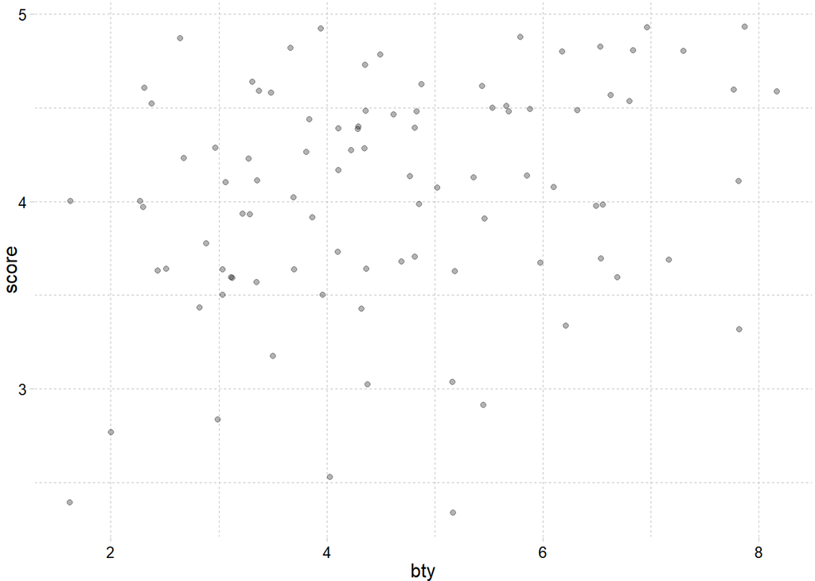

```r
ggplot(d,
       aes(x = bty,
           y = score)) +
  geom_jitter(alpha = .3)
```

It’s hard to tell how strongly (if at all) these two variables are correlated. We can do this a few different ways.

```r
d |> get_correlation(score ~ bty)     # MD wrapper function (tibble)
```

```
## # A tibble: 1 × 1
##     cor
##   <dbl>
## 1 0.265
```

```r
d |> select(score, bty) |> cor()      # base R version (matrix)
```

```
##          score      bty
## score 1.000000 0.264825
## bty   0.264825 1.000000
```

This correlation isn’t super high, but it’s not nothing. Let’s recall what the correlation means.

Linear regression is another way to summarize a bivariate (i.e., two-way) relationship between quantitative variables. It’s useful because later we can extend to more dimensions of predictors.

We are going to introduce two new functions here:

- `lm()`: a base R function that estimates a linear regression
- `get_regression_table()`: a **moderndive** function that is a wrapper on `broom::tidy()`. You are welcome to use `broom::tidy()` or something else if you’d like.

```r
mod1 <- lm(score ~ bty,
           data = d)

get_regression_table(mod1)
```

```
## # A tibble: 2 × 7
##   term      estimate std_error statistic p_value lower_ci upper_ci
##   <chr>        <dbl>     <dbl>     <dbl>   <dbl>    <dbl>    <dbl>
## 1 intercept    3.58      0.186     19.3     0       3.21     3.95
## 2 bty          0.101     0.038      2.63    0.01    0.025    0.177
```

For now, please ignore every column to the right of `estimate`. We’ll talk about that later. For now let’s consider the estimates. What do these mean?

Begin by looking at this plot.

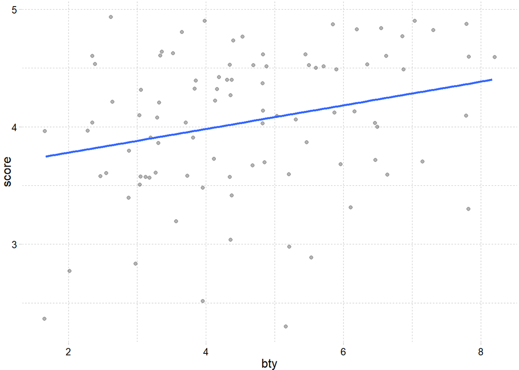

```r
ggplot(d,
       aes(x = bty,
           y = score)) +
  geom_jitter(alpha = .3) +
  geom_smooth(method = "lm",     # does this look familiar?
              se = FALSE)        # don't want to use "standard errors" for now
```

Let’s look at a slightly different version that makes the x-axis go all the way down to zero.

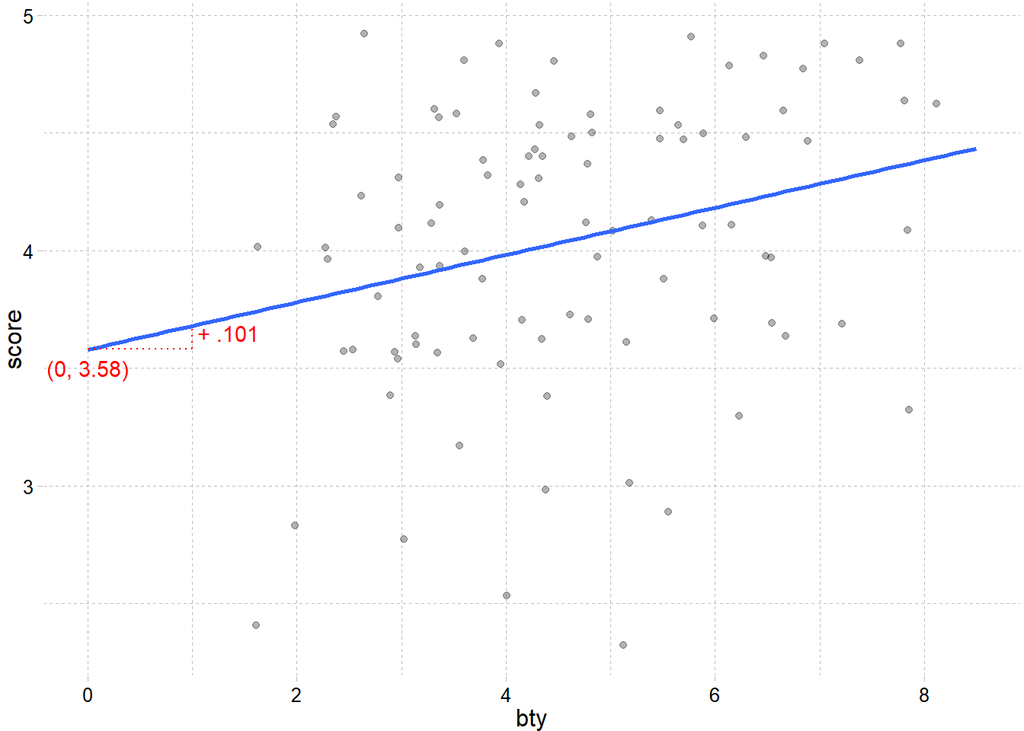

Now we have a clear picture of what these numbers mean. The **intercept** (often called $\alpha$ or “alpha”) is the expected value of $Y$ when $X = 0$. The **slope** (often called $\beta$ or “beta”) is the expected difference in $Y$ when $X$ is one unit higher.

If we wanted, we could make our `geom_smooth()` manually once we know the intercept and slope.

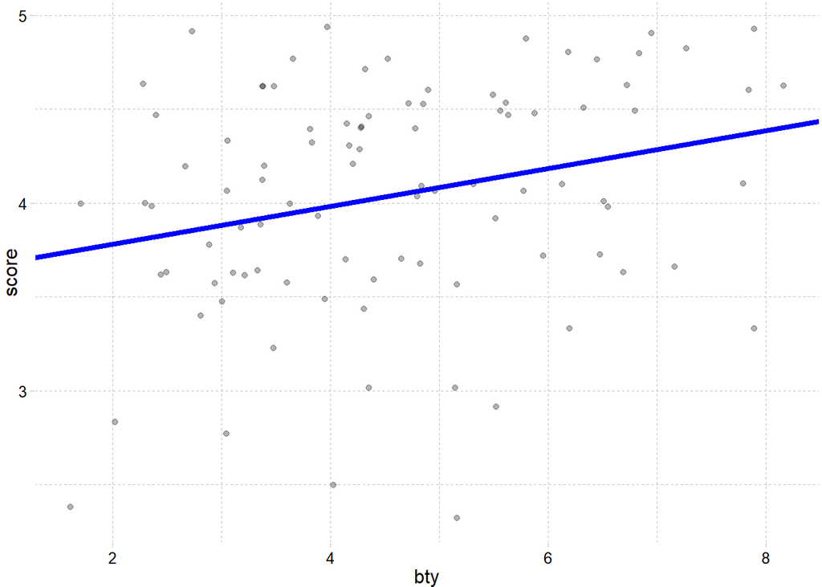

```r
p <- ggplot(d,
       aes(x = bty,
           y = score)) +
  geom_jitter(alpha = .3)

p + geom_abline(intercept = 3.58,
                slope = .101,
                color = "blue",
                size = 1.5)
```

This should look familiar from middle school. You learned the formula for a line is:

$$y = mx + b$$

In statistics, it’s a bit different:

$$\hat{y} = \alpha + \beta x$$
Why $\hat{y}$ (pronounced “y hat”)? Because as you can see, the line doesn’t pass through all the points. It’s not a *deterministic function* like a line in geometry. It’s an *expectation* that *summarizes* the relationship between two variables with a single line that is the best possible fit.

So if the intercept is 3.58 and the slope is .101, what is the expected evaluation score for an instructor with a “beauty” rating of 8? What about a “beauty” rating of 2?

## What *is* regression?

Let’s start with the idea of a normal distribution.

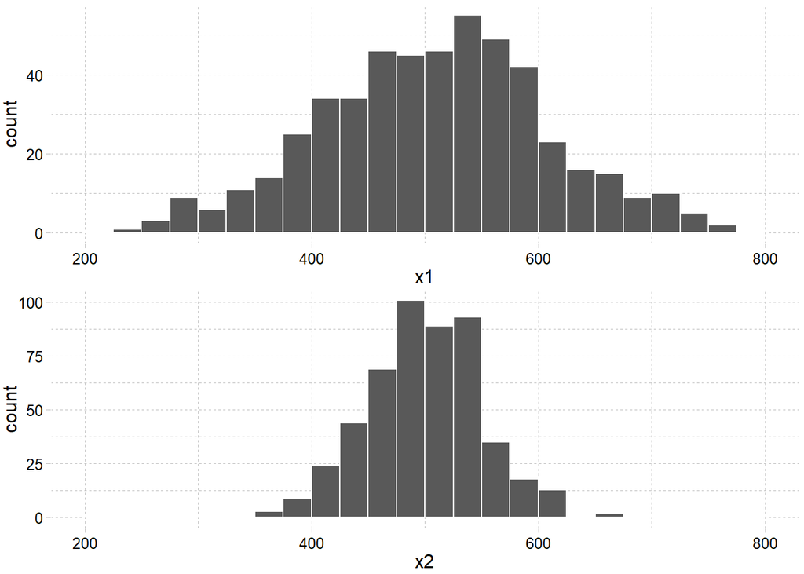

```r
set.seed(12345)
# fake data
fd <- tibble(x1 = rnorm(n = 500,
                        mean = 500,
                        sd = 100),
             x2 = rnorm(n = 500,
                        mean = 500,
                        sd = 50))
# wider SD
p1 <- ggplot(fd,
             aes(x = x1)) +
  geom_histogram(color = "white",
                 boundary = 500,
                 binwidth = 25) +
  scale_x_continuous(limits = c(200,800))

# narrower SD
p2 <- ggplot(fd,
             aes(x = x2)) +
  geom_histogram(color = "white",
                 boundary = 500,
                 binwidth = 25) +
  scale_x_continuous(limits = c(200,800))

# put together
p1 / p2
```

Formula for a normal distribution.

$$y_i \sim \text{Normal}(\mu, \sigma)$$

Formula for a linear regression.

$$\begin{aligned}y_i &\sim \text{Normal}(\mu_i, \sigma) \\\mu_i &=
\alpha + \beta x_i\end{aligned}$$

Now any value of $X$ will have it’s own **conditional mean**.